# EnsembleTechiniqueProjectFinalSubmission

```python
import pandas as pd
import numpy as np
import matplotlib.pyplot as plt
import seaborn as sns

%matplotlib inline
```

```python
df=pd.read_csv("bank-full.csv")
```

```python
df.head()
```

|  | age | job | marital | education | default | balance | housing | loan | contact | day | month | duration | campaign | pdays | previous | poutcome | Target |
| --- | --- | --- | --- | --- | --- | --- | --- | --- | --- | --- | --- | --- | --- | --- | --- | --- | --- |
| 0 | 58 | management | married | tertiary | no | 2143 | yes | no | unknown | 5 | may | 261 | 1 | -1 | 0 | unknown | no |
| 1 | 44 | technician | single | secondary | no | 29 | yes | no | unknown | 5 | may | 151 | 1 | -1 | 0 | unknown | no |
| 2 | 33 | entrepreneur | married | secondary | no | 2 | yes | yes | unknown | 5 | may | 76 | 1 | -1 | 0 | unknown | no |
| 3 | 47 | blue-collar | married | unknown | no | 1506 | yes | no | unknown | 5 | may | 92 | 1 | -1 | 0 | unknown | no |
| 4 | 33 | unknown | single | unknown | no | 1 | no | no | unknown | 5 | may | 198 | 1 | -1 | 0 | unknown | no |

```python
df.describe()
```

|  | age | balance | day | duration | campaign | pdays | previous |
| --- | --- | --- | --- | --- | --- | --- | --- |
| count | 45211.000000 | 45211.000000 | 45211.000000 | 45211.000000 | 45211.000000 | 45211.000000 | 45211.000000 |
| mean | 40.936210 | 1362.272058 | 15.806419 | 258.163080 | 2.763841 | 40.197828 | 0.580323 |
| std | 10.618762 | 3044.765829 | 8.322476 | 257.527812 | 3.098021 | 100.128746 | 2.303441 |
| min | 18.000000 | -8019.000000 | 1.000000 | 0.000000 | 1.000000 | -1.000000 | 0.000000 |
| 25% | 33.000000 | 72.000000 | 8.000000 | 103.000000 | 1.000000 | -1.000000 | 0.000000 |
| 50% | 39.000000 | 448.000000 | 16.000000 | 180.000000 | 2.000000 | -1.000000 | 0.000000 |
| 75% | 48.000000 | 1428.000000 | 21.000000 | 319.000000 | 3.000000 | -1.000000 | 0.000000 |
| max | 95.000000 | 102127.000000 | 31.000000 | 4918.000000 | 63.000000 | 871.000000 | 275.000000 |

```python
df.info()
```

```
<class 'pandas.core.frame.DataFrame'>
RangeIndex: 45211 entries, 0 to 45210
Data columns (total 17 columns):
age          45211 non-null int64
job          45211 non-null object
marital      45211 non-null object
education    45211 non-null object
default      45211 non-null object
balance      45211 non-null int64
housing      45211 non-null object
loan         45211 non-null object
contact      45211 non-null object
day          45211 non-null int64
month        45211 non-null object
duration     45211 non-null int64
campaign     45211 non-null int64
pdays        45211 non-null int64
previous     45211 non-null int64
poutcome     45211 non-null object
Target       45211 non-null object
dtypes: int64(7), object(10)
memory usage: 5.9+ MB
```

```python
df.isnull().sum()
```

```
age          0
job          0
marital      0
education    0
default      0
balance      0
housing      0
loan         0
contact      0
day          0
month        0
duration     0
campaign     0
pdays        0
previous     0
poutcome     0
Target       0
dtype: int64
```

```python
df.isna().sum()
```

```
age          0
job          0
marital      0
education    0
default      0
balance      0
housing      0
loan         0
contact      0
day          0
month        0
duration     0
campaign     0
pdays        0
previous     0
poutcome     0
Target       0
dtype: int64
```

```python
df.head()
```

|  | age | job | marital | education | default | balance | housing | loan | contact | day | month | duration | campaign | pdays | previous | poutcome | Target |
| --- | --- | --- | --- | --- | --- | --- | --- | --- | --- | --- | --- | --- | --- | --- | --- | --- | --- |
| 0 | 58 | management | married | tertiary | no | 2143 | yes | no | unknown | 5 | may | 261 | 1 | -1 | 0 | unknown | no |
| 1 | 44 | technician | single | secondary | no | 29 | yes | no | unknown | 5 | may | 151 | 1 | -1 | 0 | unknown | no |
| 2 | 33 | entrepreneur | married | secondary | no | 2 | yes | yes | unknown | 5 | may | 76 | 1 | -1 | 0 | unknown | no |
| 3 | 47 | blue-collar | married | unknown | no | 1506 | yes | no | unknown | 5 | may | 92 | 1 | -1 | 0 | unknown | no |
| 4 | 33 | unknown | single | unknown | no | 1 | no | no | unknown | 5 | may | 198 | 1 | -1 | 0 | unknown | no |

```python
df.tail()
```

|  | age | job | marital | education | default | balance | housing | loan | contact | day | month | duration | campaign | pdays | previous | poutcome | Target |
| --- | --- | --- | --- | --- | --- | --- | --- | --- | --- | --- | --- | --- | --- | --- | --- | --- | --- |
| 45206 | 51 | technician | married | tertiary | no | 825 | no | no | cellular | 17 | nov | 977 | 3 | -1 | 0 | unknown | yes |
| 45207 | 71 | retired | divorced | primary | no | 1729 | no | no | cellular | 17 | nov | 456 | 2 | -1 | 0 | unknown | yes |
| 45208 | 72 | retired | married | secondary | no | 5715 | no | no | cellular | 17 | nov | 1127 | 5 | 184 | 3 | success | yes |
| 45209 | 57 | blue-collar | married | secondary | no | 668 | no | no | telephone | 17 | nov | 508 | 4 | -1 | 0 | unknown | no |
| 45210 | 37 | entrepreneur | married | secondary | no | 2971 | no | no | cellular | 17 | nov | 361 | 2 | 188 | 11 | other | no |

```python
df.isnull().sum()
```

```
age          0
job          0
marital      0
education    0
default      0
balance      0
housing      0
loan         0
contact      0
day          0
month        0
duration     0
campaign     0
pdays        0
previous     0
poutcome     0
Target       0
dtype: int64
```

```python
dfCopiedData=df.copy()
```

```python
dfCopiedData.info()
```

```
<class 'pandas.core.frame.DataFrame'>
RangeIndex: 45211 entries, 0 to 45210
Data columns (total 17 columns):
age          45211 non-null int64
job          45211 non-null object
marital      45211 non-null object
education    45211 non-null object
default      45211 non-null object
balance      45211 non-null int64
housing      45211 non-null object
loan         45211 non-null object
contact      45211 non-null object
day          45211 non-null int64
month        45211 non-null object
duration     45211 non-null int64
campaign     45211 non-null int64
pdays        45211 non-null int64
previous     45211 non-null int64
poutcome     45211 non-null object
Target       45211 non-null object
dtypes: int64(7), object(10)
memory usage: 5.9+ MB
```

```python
# Converting copied data Target column to Numeric
dfCopiedData["Target"] = dfCopiedData["Target"].astype('category')
dfCopiedData.dtypes
```

```
age             int64
job            object
marital        object
education      object
default        object
balance         int64
housing        object
loan           object
contact        object
day             int64
month          object
duration        int64
campaign        int64
pdays           int64
previous        int64
poutcome       object
Target       category
dtype: object
```

```python
dfCopiedData["Target"] = dfCopiedData["Target"].cat.codes
dfCopiedData.head()
```

|  | age | job | marital | education | default | balance | housing | loan | contact | day | month | duration | campaign | pdays | previous | poutcome | Target |
| --- | --- | --- | --- | --- | --- | --- | --- | --- | --- | --- | --- | --- | --- | --- | --- | --- | --- |
| 0 | 58 | management | married | tertiary | no | 2143 | yes | no | unknown | 5 | may | 261 | 1 | -1 | 0 | unknown | 0 |
| 1 | 44 | technician | single | secondary | no | 29 | yes | no | unknown | 5 | may | 151 | 1 | -1 | 0 | unknown | 0 |
| 2 | 33 | entrepreneur | married | secondary | no | 2 | yes | yes | unknown | 5 | may | 76 | 1 | -1 | 0 | unknown | 0 |
| 3 | 47 | blue-collar | married | unknown | no | 1506 | yes | no | unknown | 5 | may | 92 | 1 | -1 | 0 | unknown | 0 |
| 4 | 33 | unknown | single | unknown | no | 1 | no | no | unknown | 5 | may | 198 | 1 | -1 | 0 | unknown | 0 |

**Age Attribute Observations**

```python
DtypeOfAgeVAriable=dfCopiedData['age'].dtype
DtypeOfAgeVAriable
```

```
dtype('int64')
```

```python
dfCopiedData['age'].describe()
```

```
count    45211.000000
mean        40.936210
std         10.618762
min         18.000000
25%         33.000000
50%         39.000000
75%         48.000000
max         95.000000
Name: age, dtype: float64
```

```python
dfCopiedData['age'].median()
```

```
39.0
```

```python
dfCopiedData['age'].tail()
```

```
45206    51
45207    71
45208    72
45209    57
45210    37
Name: age, dtype: int64
```

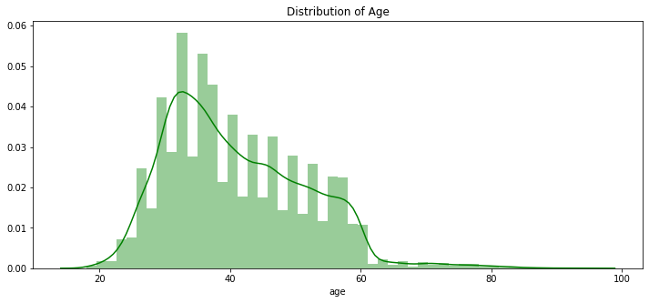

```python
plt.figure(figsize=(12,5))
plt.title("Distribution of Age")
ax = sns.distplot(dfCopiedData["age"], color = 'g')
```

```python
dfCopiedData['age'].isna().sum()
```

```
0
```

```python
dfCopiedData['age'].isnull().sum()
```

```
0
```

```python
dfCopiedData['age'].value_counts()
```

```
32    2085
31    1996
33    1972
34    1930
35    1894
36    1806
30    1757
37    1696
39    1487
38    1466
40    1355
41    1291
42    1242
45    1216
29    1185
```

[output cut: 47 more lines]

```python
dfCopiedData['age'].value_counts().sum()
```

```
45211
```

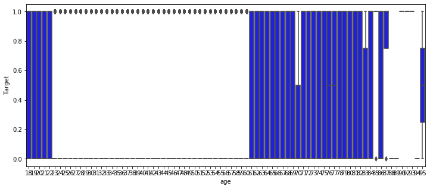

```python
plt.figure(figsize=(12,5))
sns.boxplot(x='age',y='Target',data=dfCopiedData,color='b')
plt.show()
```

```python
pd.qcut(dfCopiedData['age'], q=4)
```

```
0          (48.0, 95.0]
1          (39.0, 48.0]
2        (17.999, 33.0]
3          (39.0, 48.0]
4        (17.999, 33.0]
5          (33.0, 39.0]
6        (17.999, 33.0]
7          (39.0, 48.0]
8          (48.0, 95.0]
9          (39.0, 48.0]
10         (39.0, 48.0]
11       (17.999, 33.0]
12         (48.0, 95.0]
13         (48.0, 95.0]
14         (48.0, 95.0]
```

[output cut: 48 more lines]

**Job Attribute Observations**

```python
DtypeOfJObVariable=dfCopiedData['job'].dtype
DtypeOfJObVariable
```

```
dtype('O')
```

```python
dfCopiedData['job'].describe()
```

```
count           45211
unique             12
top       blue-collar
freq             9732
Name: job, dtype: object
```

```python
dfCopiedData['job'].isna().sum()
```

```
0
```

```python
dfCopiedData['job'].isnull().sum()
```

```
0
```

```python
dfCopiedData['job'].value_counts()
```

```
blue-collar      9732
management       9458
technician       7597
admin.           5171
services         4154
retired          2264
self-employed    1579
entrepreneur     1487
unemployed       1303
housemaid        1240
student           938
unknown           288
Name: job, dtype: int64
```

```python
dfCopiedData['job'].value_counts().sum()
```

```
45211
```

```python
dfCopiedData['job'].tail()
```

```
45206      technician
45207         retired
45208         retired
45209     blue-collar
45210    entrepreneur
Name: job, dtype: object
```

```python
dfCopiedData.groupby(['job']).mean()
```

| job | age | balance | day | duration | campaign | pdays | previous | Target |
| --- | --- | --- | --- | --- | --- | --- | --- | --- |
| admin. | 39.289886 | 1135.838909 | 15.564301 | 246.896732 | 2.575324 | 47.859021 | 0.671630 | 0.122027 |
| blue-collar | 40.044081 | 1078.826654 | 15.442561 | 262.901562 | 2.816995 | 44.033498 | 0.505138 | 0.072750 |
| entrepreneur | 42.190989 | 1521.470074 | 15.702085 | 256.309348 | 2.799597 | 32.486214 | 0.478144 | 0.082717 |
| housemaid | 46.415323 | 1392.395161 | 16.002419 | 245.825000 | 2.820968 | 21.505645 | 0.371774 | 0.087903 |
| management | 40.449567 | 1763.616832 | 16.114189 | 253.995771 | 2.864348 | 38.665468 | 0.668006 | 0.137556 |
| retired | 61.626767 | 1984.215106 | 15.439488 | 287.361307 | 2.346731 | 37.443905 | 0.638693 | 0.227915 |
| self-employed | 40.484484 | 1647.970868 | 16.027866 | 268.157061 | 2.853072 | 34.747308 | 0.551615 | 0.118429 |
| services | 38.740250 | 997.088108 | 15.635532 | 259.318729 | 2.718344 | 41.995185 | 0.501204 | 0.088830 |
| student | 26.542644 | 1388.060768 | 14.897655 | 246.656716 | 2.299574 | 57.041578 | 0.953092 | 0.286780 |
| technician | 39.314598 | 1252.632092 | 16.408582 | 252.904962 | 2.906805 | 37.195077 | 0.574569 | 0.110570 |
| unemployed | 40.961627 | 1521.745971 | 15.498081 | 288.543361 | 2.432080 | 34.146585 | 0.466616 | 0.155027 |
| unknown | 47.593750 | 1772.357639 | 14.642361 | 237.611111 | 3.309028 | 20.982639 | 0.319444 | 0.118056 |

```python
dfCopiedData.groupby(['job']).std()
```

| job | age | balance | day | duration | campaign | pdays | previous | Target |
| --- | --- | --- | --- | --- | --- | --- | --- | --- |
| admin. | 9.365483 | 2641.962686 | 8.464414 | 239.784640 | 2.950311 | 108.711348 | 2.014955 | 0.327348 |
| blue-collar | 9.025888 | 2240.523208 | 7.886832 | 260.758862 | 3.242741 | 109.726424 | 1.853396 | 0.259739 |
| entrepreneur | 9.114486 | 4153.442626 | 7.883788 | 247.732261 | 2.855926 | 88.046350 | 1.807164 | 0.275546 |
| housemaid | 10.477275 | 2984.692098 | 8.091037 | 259.380688 | 2.800071 | 71.077241 | 1.382355 | 0.283268 |
| management | 9.383415 | 3822.965605 | 8.381946 | 256.843861 | 3.203390 | 97.086456 | 3.522605 | 0.344451 |
| retired | 9.535329 | 4397.044177 | 8.320994 | 263.806848 | 2.269981 | 87.009624 | 1.727894 | 0.419580 |
| self-employed | 9.656075 | 3684.259573 | 8.214904 | 281.908745 | 3.186624 | 87.798783 | 1.713390 | 0.323218 |
| services | 9.041371 | 2164.493505 | 8.295096 | 259.787395 | 3.044436 | 103.797862 | 1.620101 | 0.284533 |
| student | 4.842536 | 2441.703526 | 8.801146 | 228.409973 | 2.341865 | 106.818847 | 2.386805 | 0.452499 |
| technician | 8.939944 | 2548.544019 | 8.527777 | 256.498164 | 3.284196 | 94.993072 | 1.967449 | 0.313620 |
| unemployed | 9.777010 | 3144.666754 | 9.415146 | 290.049195 | 2.633201 | 94.431841 | 1.537123 | 0.362069 |
| unknown | 10.775095 | 2970.288559 | 8.630261 | 226.115296 | 3.788621 | 75.652767 | 1.089403 | 0.323236 |

```python
dfCopiedData.groupby(['job']).median()
```

| job | age | balance | day | duration | campaign | pdays | previous | Target |
| --- | --- | --- | --- | --- | --- | --- | --- | --- |
| admin. | 38.0 | 396.0 | 15.0 | 174.0 | 2.0 | -1.0 | 0.0 | 0 |
| blue-collar | 39.0 | 388.0 | 15.0 | 186.0 | 2.0 | -1.0 | 0.0 | 0 |
| entrepreneur | 41.0 | 352.0 | 17.0 | 178.0 | 2.0 | -1.0 | 0.0 | 0 |
| housemaid | 47.0 | 406.0 | 16.0 | 163.0 | 2.0 | -1.0 | 0.0 | 0 |
| management | 38.0 | 572.0 | 17.0 | 173.0 | 2.0 | -1.0 | 0.0 | 0 |
| retired | 59.0 | 787.0 | 15.0 | 204.0 | 2.0 | -1.0 | 0.0 | 0 |
| self-employed | 39.0 | 526.0 | 17.0 | 179.0 | 2.0 | -1.0 | 0.0 | 0 |
| services | 37.0 | 339.5 | 16.0 | 186.0 | 2.0 | -1.0 | 0.0 | 0 |
| student | 26.0 | 502.0 | 14.0 | 180.0 | 2.0 | -1.0 | 0.0 | 0 |
| technician | 37.0 | 421.0 | 17.0 | 176.0 | 2.0 | -1.0 | 0.0 | 0 |
| unemployed | 40.0 | 529.0 | 15.0 | 200.0 | 2.0 | -1.0 | 0.0 | 0 |
| unknown | 47.0 | 677.0 | 14.0 | 165.0 | 2.0 | -1.0 | 0.0 | 0 |

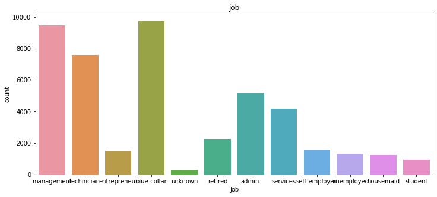

```python
plt.figure(figsize=(12,5))
plt.title('job')
sns.countplot(x='job',data=dfCopiedData)
plt.show()
```

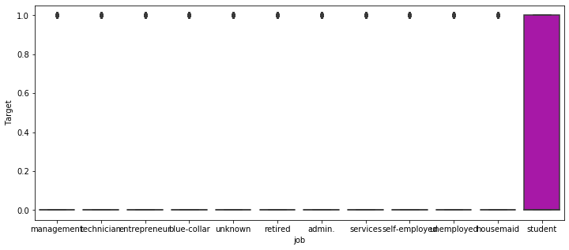

```python
plt.figure(figsize=(12,5))
sns.boxplot(x="job",y="Target",data=dfCopiedData,color='m')
plt.show()
```

```python
#marital
```

```python
DtypeOfMaritalVAriable=dfCopiedData['marital'].dtype
DtypeOfMaritalVAriable
```

```
dtype('O')
```

```python
dfCopiedData['marital'].describe().transpose()
```

```
count       45211
unique          3
top       married
freq        27214
Name: marital, dtype: object
```

```python
dfCopiedData['marital'].tail()
```

```
45206     married
45207    divorced
45208     married
45209     married
45210     married
Name: marital, dtype: object
```

```python
dfCopiedData['marital'].isna().sum()
```

```
0
```

```python
dfCopiedData['marital'].isnull().sum()
```

```
0
```

```python
dfCopiedData['marital'].value_counts()
```

```
married     27214
single      12790
divorced     5207
Name: marital, dtype: int64
```

```python
dfCopiedData['marital'].value_counts().sum()
```

```
45211
```

```python
dfCopiedData.groupby(['marital']).mean()
```

| marital | age | balance | day | duration | campaign | pdays | previous | Target |
| --- | --- | --- | --- | --- | --- | --- | --- | --- |
| divorced | 45.782984 | 1178.872287 | 15.796428 | 262.517188 | 2.630882 | 41.001728 | 0.551373 | 0.119455 |
| married | 43.408099 | 1425.925590 | 15.854487 | 253.412765 | 2.842875 | 37.950467 | 0.556552 | 0.101235 |
| single | 33.703440 | 1301.497654 | 15.708210 | 266.497967 | 2.649805 | 44.652385 | 0.642690 | 0.149492 |

```python
dfCopiedData.groupby(['marital']).std()
```

| marital | age | balance | day | duration | campaign | pdays | previous | Target |
| --- | --- | --- | --- | --- | --- | --- | --- | --- |
| divorced | 10.124719 | 2926.453439 | 8.262271 | 263.807016 | 2.796826 | 102.327149 | 1.811625 | 0.324354 |
| married | 10.264452 | 3140.962597 | 8.226741 | 253.164471 | 3.146143 | 97.227581 | 2.478797 | 0.301645 |
| single | 7.603166 | 2875.317791 | 8.546200 | 263.845968 | 3.106302 | 105.041069 | 2.083432 | 0.356587 |

```python
dfCopiedData.groupby(['marital']).median()
```

| marital | age | balance | day | duration | campaign | pdays | previous | Target |
| --- | --- | --- | --- | --- | --- | --- | --- | --- |
| divorced | 45 | 348 | 16 | 178 | 2 | -1 | 0 | 0 |
| married | 42 | 477 | 16 | 177 | 2 | -1 | 0 | 0 |
| single | 32 | 437 | 16 | 187 | 2 | -1 | 0 | 0 |

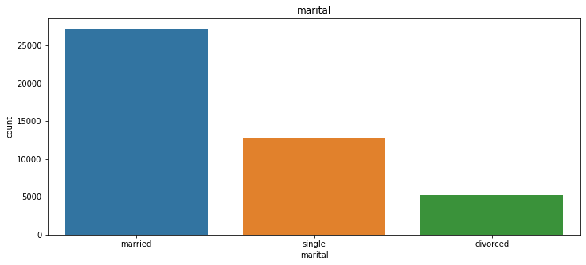

```python
plt.figure(figsize=(12,5))
plt.title('marital')
sns.countplot(x='marital',data=dfCopiedData)
plt.show()
```

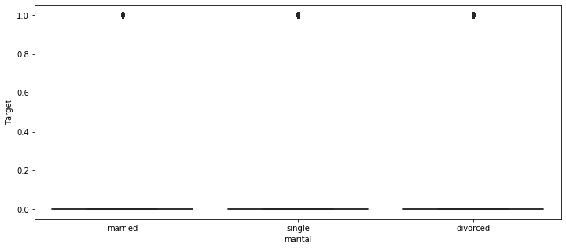

```python
# Univariant Analysis
plt.figure(figsize=(12,5))
sns.boxplot(x="marital",y="Target",data=dfCopiedData,color='g')
plt.show()
```

```python
dfCopiedData.head()
```

|  | age | job | marital | education | default | balance | housing | loan | contact | day | month | duration | campaign | pdays | previous | poutcome | Target |
| --- | --- | --- | --- | --- | --- | --- | --- | --- | --- | --- | --- | --- | --- | --- | --- | --- | --- |
| 0 | 58 | management | married | tertiary | no | 2143 | yes | no | unknown | 5 | may | 261 | 1 | -1 | 0 | unknown | 0 |
| 1 | 44 | technician | single | secondary | no | 29 | yes | no | unknown | 5 | may | 151 | 1 | -1 | 0 | unknown | 0 |
| 2 | 33 | entrepreneur | married | secondary | no | 2 | yes | yes | unknown | 5 | may | 76 | 1 | -1 | 0 | unknown | 0 |
| 3 | 47 | blue-collar | married | unknown | no | 1506 | yes | no | unknown | 5 | may | 92 | 1 | -1 | 0 | unknown | 0 |
| 4 | 33 | unknown | single | unknown | no | 1 | no | no | unknown | 5 | may | 198 | 1 | -1 | 0 | unknown | 0 |

```python
# Education
```

```python
DtypeOfEducationVariable=dfCopiedData['education'].dtype
DtypeOfEducationVariable
```

```
dtype('O')
```

```python
dfCopiedData['education'].describe().transpose()
```

```
count         45211
unique            4
top       secondary
freq          23202
Name: education, dtype: object
```

```python
dfCopiedData['education'].tail()
```

```
45206     tertiary
45207      primary
45208    secondary
45209    secondary
45210    secondary
Name: education, dtype: object
```

```python
dfCopiedData['education'].isna().sum()
```

```
0
```

```python
dfCopiedData['education'].isnull().sum()
```

```
0
```

```python
dfCopiedData['education'].value_counts()
```

```
secondary    23202
tertiary     13301
primary       6851
unknown       1857
Name: education, dtype: int64
```

```python
dfCopiedData['education'].value_counts().sum()
```

```
45211
```

```python
dfCopiedData.groupby(['education']).mean()
```

| education | age | balance | day | duration | campaign | pdays | previous | Target |
| --- | --- | --- | --- | --- | --- | --- | --- | --- |
| primary | 45.865567 | 1250.949934 | 15.421398 | 255.933002 | 2.834331 | 36.081740 | 0.489272 | 0.086265 |
| secondary | 39.964270 | 1154.880786 | 15.759159 | 258.685760 | 2.700802 | 42.353504 | 0.567753 | 0.105594 |
| tertiary | 39.593640 | 1758.416435 | 16.086535 | 258.518532 | 2.825577 | 39.024134 | 0.661980 | 0.150064 |
| unknown | 44.510501 | 1526.754443 | 15.810985 | 257.313947 | 2.849219 | 36.856220 | 0.488422 | 0.135703 |

```python
dfCopiedData.groupby(['education']).std()
```

| education | age | balance | day | duration | campaign | pdays | previous | Target |
| --- | --- | --- | --- | --- | --- | --- | --- | --- |
| primary | 11.401980 | 2690.743991 | 7.975752 | 260.279981 | 3.166683 | 97.557124 | 1.897365 | 0.280775 |
| secondary | 10.159568 | 2558.256739 | 8.307099 | 253.310692 | 2.985786 | 103.589692 | 1.849867 | 0.307324 |
| tertiary | 9.887923 | 3839.088305 | 8.462004 | 264.938057 | 3.146753 | 95.780024 | 3.139468 | 0.357147 |
| unknown | 12.196400 | 3152.228273 | 8.689590 | 245.622775 | 3.778611 | 95.226077 | 1.569167 | 0.342565 |

```python
dfCopiedData.groupby(['education']).median()
```

| education | age | balance | day | duration | campaign | pdays | previous | Target |
| --- | --- | --- | --- | --- | --- | --- | --- | --- |
| primary | 45 | 403 | 15 | 178 | 2 | -1 | 0 | 0 |
| secondary | 38 | 392 | 16 | 183 | 2 | -1 | 0 | 0 |
| tertiary | 37 | 577 | 17 | 176 | 2 | -1 | 0 | 0 |
| unknown | 45 | 568 | 16 | 180 | 2 | -1 | 0 | 0 |

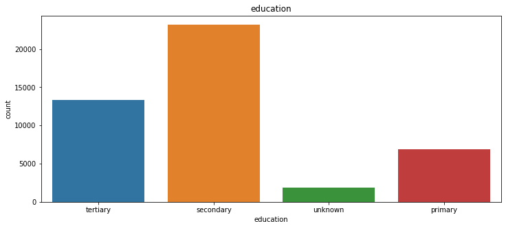

```python
plt.figure(figsize=(12,5))
plt.title('education')
sns.countplot(x='education',data=dfCopiedData)
plt.show()
```

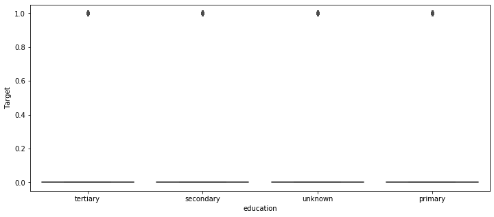

```python
# Univariant Analysis
plt.figure(figsize=(12,5))
sns.boxplot(x="education",y="Target",data=dfCopiedData,color='b')
plt.show()
```

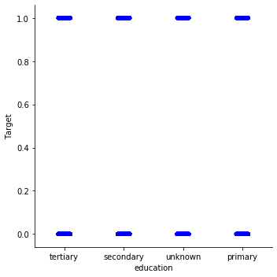

```python
plt.figure(figsize=(12,5))
sns.catplot(x="education",y="Target",data=dfCopiedData,color='b')
plt.show()
```

```python
dfCopiedData.head()
```

|  | age | job | marital | education | default | balance | housing | loan | contact | day | month | duration | campaign | pdays | previous | poutcome | Target |
| --- | --- | --- | --- | --- | --- | --- | --- | --- | --- | --- | --- | --- | --- | --- | --- | --- | --- |
| 0 | 58 | management | married | tertiary | no | 2143 | yes | no | unknown | 5 | may | 261 | 1 | -1 | 0 | unknown | 0 |
| 1 | 44 | technician | single | secondary | no | 29 | yes | no | unknown | 5 | may | 151 | 1 | -1 | 0 | unknown | 0 |
| 2 | 33 | entrepreneur | married | secondary | no | 2 | yes | yes | unknown | 5 | may | 76 | 1 | -1 | 0 | unknown | 0 |
| 3 | 47 | blue-collar | married | unknown | no | 1506 | yes | no | unknown | 5 | may | 92 | 1 | -1 | 0 | unknown | 0 |
| 4 | 33 | unknown | single | unknown | no | 1 | no | no | unknown | 5 | may | 198 | 1 | -1 | 0 | unknown | 0 |

```python
# Will change default to Numerical by Label Encoding
dfCopiedData['default']=dfCopiedData['default'].astype('category')
```

```python
dfCopiedData.dtypes
```

```
age             int64
job            object
marital        object
education      object
default      category
balance         int64
housing        object
loan           object
contact        object
day             int64
month          object
duration        int64
campaign        int64
pdays           int64
previous        int64
poutcome       object
Target           int8
dtype: object
```

```python
dfCopiedData['default']=dfCopiedData['default'].cat.codes
dfCopiedData.head()
```

|  | age | job | marital | education | default | balance | housing | loan | contact | day | month | duration | campaign | pdays | previous | poutcome | Target |
| --- | --- | --- | --- | --- | --- | --- | --- | --- | --- | --- | --- | --- | --- | --- | --- | --- | --- |
| 0 | 58 | management | married | tertiary | 0 | 2143 | yes | no | unknown | 5 | may | 261 | 1 | -1 | 0 | unknown | 0 |
| 1 | 44 | technician | single | secondary | 0 | 29 | yes | no | unknown | 5 | may | 151 | 1 | -1 | 0 | unknown | 0 |
| 2 | 33 | entrepreneur | married | secondary | 0 | 2 | yes | yes | unknown | 5 | may | 76 | 1 | -1 | 0 | unknown | 0 |
| 3 | 47 | blue-collar | married | unknown | 0 | 1506 | yes | no | unknown | 5 | may | 92 | 1 | -1 | 0 | unknown | 0 |
| 4 | 33 | unknown | single | unknown | 0 | 1 | no | no | unknown | 5 | may | 198 | 1 | -1 | 0 | unknown | 0 |

```python
# Default
```

```python
DtypeOfdefaultVAriable=dfCopiedData['default'].dtype
DtypeOfdefaultVAriable
```

```
dtype('int8')
```

```python
dfCopiedData['default'].describe().transpose()
```

```
count    45211.000000
mean         0.018027
std          0.133049
min          0.000000
25%          0.000000
50%          0.000000
75%          0.000000
max          1.000000
Name: default, dtype: float64
```

```python
dfCopiedData['default'].tail()
```

```
45206    0
45207    0
45208    0
45209    0
45210    0
Name: default, dtype: int8
```

```python
dfCopiedData['default'].isna().sum()
```

```
0
```

```python
dfCopiedData['default'].isnull().sum()
```

```
0
```

```python
dfCopiedData['default'].value_counts()
```

```
0    44396
1      815
Name: default, dtype: int64
```

```python
dfCopiedData['default'].value_counts().sum()
```

```
45211
```

```python
dfCopiedData.groupby(['default']).mean()
```

| default | age | balance | day | duration | campaign | pdays | previous | Target |
| --- | --- | --- | --- | --- | --- | --- | --- | --- |
| 0 | 40.961934 | 1389.806424 | 15.795792 | 258.512749 | 2.756780 | 40.604536 | 0.586044 | 0.117961 |
| 1 | 39.534969 | -137.624540 | 16.385276 | 239.115337 | 3.148466 | 18.042945 | 0.268712 | 0.063804 |

```python
dfCopiedData.groupby(['default']).std()
```

| default | age | balance | day | duration | campaign | pdays | previous | Target |
| --- | --- | --- | --- | --- | --- | --- | --- | --- |
| 0 | 10.638882 | 3063.275425 | 8.317696 | 258.239396 | 3.087038 | 100.504630 | 2.313596 | 0.322566 |
| 1 | 9.357804 | 906.704678 | 8.564183 | 214.512375 | 3.628145 | 73.651493 | 1.629787 | 0.244553 |

```python
dfCopiedData.groupby(['default']).median()
```

| default | age | balance | day | duration | campaign | pdays | previous | Target |
| --- | --- | --- | --- | --- | --- | --- | --- | --- |
| 0 | 39 | 468 | 16 | 180 | 2 | -1 | 0 | 0 |
| 1 | 38 | -7 | 17 | 172 | 2 | -1 | 0 | 0 |

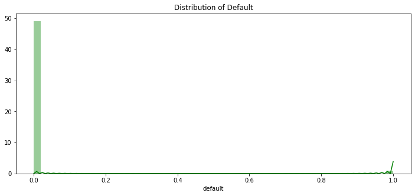

```python
plt.figure(figsize=(12,5))
plt.title("Distribution of Default")
ax = sns.distplot(dfCopiedData["default"], color = 'g')
```

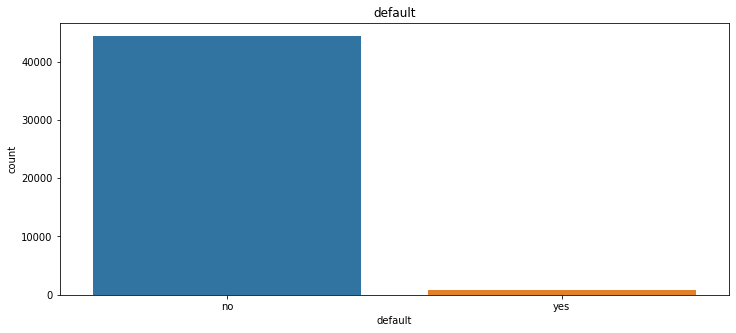

```python
plt.figure(figsize=(12,5))
plt.title('default')
sns.countplot(x='default',data=df)
plt.show()
```

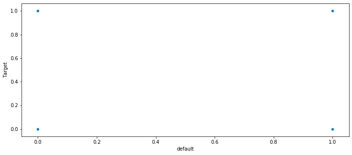

```python
# Univariant Analysis
plt.figure(figsize=(12,5))
sns.scatterplot(x='default',y='Target',data=dfCopiedData)
plt.show()
```

```python
dfCopiedData.head()
```

|  | age | job | marital | education | default | balance | housing | loan | contact | day | month | duration | campaign | pdays | previous | poutcome | Target |
| --- | --- | --- | --- | --- | --- | --- | --- | --- | --- | --- | --- | --- | --- | --- | --- | --- | --- |
| 0 | 58 | management | married | tertiary | 0 | 2143 | yes | no | unknown | 5 | may | 261 | 1 | -1 | 0 | unknown | 0 |
| 1 | 44 | technician | single | secondary | 0 | 29 | yes | no | unknown | 5 | may | 151 | 1 | -1 | 0 | unknown | 0 |
| 2 | 33 | entrepreneur | married | secondary | 0 | 2 | yes | yes | unknown | 5 | may | 76 | 1 | -1 | 0 | unknown | 0 |
| 3 | 47 | blue-collar | married | unknown | 0 | 1506 | yes | no | unknown | 5 | may | 92 | 1 | -1 | 0 | unknown | 0 |
| 4 | 33 | unknown | single | unknown | 0 | 1 | no | no | unknown | 5 | may | 198 | 1 | -1 | 0 | unknown | 0 |

```python
# Balance
```

```python
DtypeOfbalanceVAriable=dfCopiedData['balance'].dtype
DtypeOfbalanceVAriable
```

```
dtype('int64')
```

```python
dfCopiedData['balance'].describe().transpose()
```

```
count     45211.000000
mean       1362.272058
std        3044.765829
min       -8019.000000
25%          72.000000
50%         448.000000
75%        1428.000000
max      102127.000000
Name: balance, dtype: float64
```

```python
dfCopiedData['balance'].tail()
```

```
45206     825
45207    1729
45208    5715
45209     668
45210    2971
Name: balance, dtype: int64
```

```python
dfCopiedData['balance'].isna().sum()
```

```
0
```

```python
dfCopiedData['balance'].isnull().sum()
```

```
0
```

```python
dfCopiedData['balance'].value_counts()
```

```
 0        3514
 1         195
 2         156
 4         139
 3         134
 5         113
 6          88
 8          81
 23         75
 10         69
 7          69
 11         65
 25         63
 20         62
 19         60
```

[output cut: 47 more lines]

```python
dfCopiedData['balance'].value_counts().sum()
```

```
45211
```

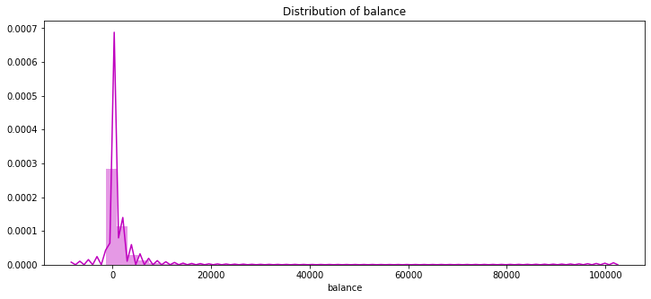

```python
plt.figure(figsize=(12,5))
plt.title("Distribution of balance")
ax = sns.distplot(dfCopiedData["balance"], color = 'm')
```

[output not shown]

[output cut: 37 more lines]

[output not shown]

[output not shown]

[output not shown]

[output cut: 60 more lines]

[output not shown]

[figure not shown]

```python
plt.figure(figsize=(12,5))
sns.boxplot(x="balance",y="Target",data=dfCopiedData,color='g')
plt.show()
```

```python
plt.figure(figsize=(12,5))
sns.catplot(x="balance",y="Target",data=dfCopiedData,color='g')
plt.show()
```

[output not shown]

```python
dfCopiedData.head()
```

|  | age | job | marital | education | default | balance | housing | loan | contact | day | month | duration | campaign | pdays | previous | poutcome | Target |
| --- | --- | --- | --- | --- | --- | --- | --- | --- | --- | --- | --- | --- | --- | --- | --- | --- | --- |
| 0 | 58 | management | married | tertiary | 0 | 2143 | yes | no | unknown | 5 | may | 261 | 1 | -1 | 0 | unknown | 0 |
| 1 | 44 | technician | single | secondary | 0 | 29 | yes | no | unknown | 5 | may | 151 | 1 | -1 | 0 | unknown | 0 |
| 2 | 33 | entrepreneur | married | secondary | 0 | 2 | yes | yes | unknown | 5 | may | 76 | 1 | -1 | 0 | unknown | 0 |
| 3 | 47 | blue-collar | married | unknown | 0 | 1506 | yes | no | unknown | 5 | may | 92 | 1 | -1 | 0 | unknown | 0 |
| 4 | 33 | unknown | single | unknown | 0 | 1 | no | no | unknown | 5 | may | 198 | 1 | -1 | 0 | unknown | 0 |

```python
dfCopiedData['housing']
```

```
0        yes
1        yes
2        yes
3        yes
4         no
5        yes
6        yes
7        yes
8        yes
9        yes
10       yes
11       yes
12       yes
13       yes
14       yes
```

[output cut: 47 more lines]

```python
# Housing to be changed to numeric by label encoding
```

```python
dfCopiedData['housing']=dfCopiedData['housing'].astype('category')
dfCopiedData.dtypes
```

```
age             int64
job            object
marital        object
education      object
default          int8
balance         int64
housing      category
loan           object
contact        object
day             int64
month          object
duration        int64
campaign        int64
pdays           int64
previous        int64
poutcome       object
Target           int8
dtype: object
```

```python
dfCopiedData['housing']=dfCopiedData['housing'].cat.codes
dfCopiedData.head()
```

|  | age | job | marital | education | default | balance | housing | loan | contact | day | month | duration | campaign | pdays | previous | poutcome | Target |
| --- | --- | --- | --- | --- | --- | --- | --- | --- | --- | --- | --- | --- | --- | --- | --- | --- | --- |
| 0 | 58 | management | married | tertiary | 0 | 2143 | 1 | no | unknown | 5 | may | 261 | 1 | -1 | 0 | unknown | 0 |
| 1 | 44 | technician | single | secondary | 0 | 29 | 1 | no | unknown | 5 | may | 151 | 1 | -1 | 0 | unknown | 0 |
| 2 | 33 | entrepreneur | married | secondary | 0 | 2 | 1 | yes | unknown | 5 | may | 76 | 1 | -1 | 0 | unknown | 0 |
| 3 | 47 | blue-collar | married | unknown | 0 | 1506 | 1 | no | unknown | 5 | may | 92 | 1 | -1 | 0 | unknown | 0 |
| 4 | 33 | unknown | single | unknown | 0 | 1 | 0 | no | unknown | 5 | may | 198 | 1 | -1 | 0 | unknown | 0 |

```python
dfCopiedData['housing'].value_counts()
```

```
1    25130
0    20081
Name: housing, dtype: int64
```

```python
DtypeOfhousingVAriable=dfCopiedData['housing'].dtype
DtypeOfhousingVAriable
```

```
dtype('int8')
```

```python
dfCopiedData['housing'].describe().transpose()
```

```
count    45211.000000
mean         0.555838
std          0.496878
min          0.000000
25%          0.000000
50%          1.000000
75%          1.000000
max          1.000000
Name: housing, dtype: float64
```

```python
dfCopiedData['housing'].tail()
```

```
45206    0
45207    0
45208    0
45209    0
45210    0
Name: housing, dtype: int8
```

```python
dfCopiedData['housing'].isna().sum()
```

```
0
```

```python
dfCopiedData['housing'].isnull().sum()
```

```
0
```

```python
dfCopiedData['housing'].value_counts()
```

```
1    25130
0    20081
Name: housing, dtype: int64
```

```python
dfCopiedData['housing'].value_counts().sum()
```

```
45211
```

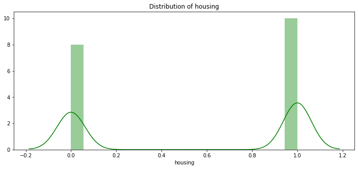

```python
plt.figure(figsize=(12,5))
plt.title("Distribution of housing")
ax = sns.distplot(dfCopiedData["housing"], color = 'g')
```

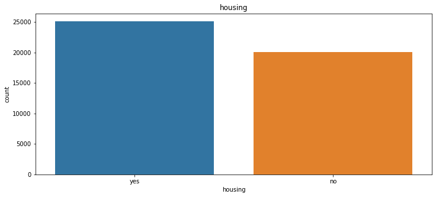

```python
plt.figure(figsize=(12,5))
plt.title('housing')
sns.countplot(x='housing',data=df)
plt.show()
```

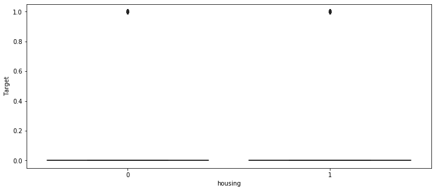

```python
# Univariant Analysis
plt.figure(figsize=(12,5))
sns.boxplot(x="housing",y="Target",data=dfCopiedData,color='g')
plt.show()
```

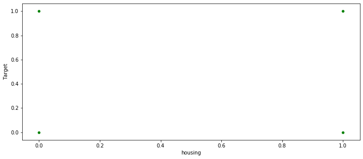

```python
# Univariant Analysis
plt.figure(figsize=(12,5))
sns.scatterplot(x="housing",y="Target",data=dfCopiedData,color='g')
plt.show()
```

```python
dfCopiedData.head()
```

|  | age | job | marital | education | default | balance | housing | loan | contact | day | month | duration | campaign | pdays | previous | poutcome | Target |
| --- | --- | --- | --- | --- | --- | --- | --- | --- | --- | --- | --- | --- | --- | --- | --- | --- | --- |
| 0 | 58 | management | married | tertiary | 0 | 2143 | 1 | no | unknown | 5 | may | 261 | 1 | -1 | 0 | unknown | 0 |
| 1 | 44 | technician | single | secondary | 0 | 29 | 1 | no | unknown | 5 | may | 151 | 1 | -1 | 0 | unknown | 0 |
| 2 | 33 | entrepreneur | married | secondary | 0 | 2 | 1 | yes | unknown | 5 | may | 76 | 1 | -1 | 0 | unknown | 0 |
| 3 | 47 | blue-collar | married | unknown | 0 | 1506 | 1 | no | unknown | 5 | may | 92 | 1 | -1 | 0 | unknown | 0 |
| 4 | 33 | unknown | single | unknown | 0 | 1 | 0 | no | unknown | 5 | may | 198 | 1 | -1 | 0 | unknown | 0 |

```python
dfCopiedData['loan'].value_counts()
```

```
no     37967
yes     7244
Name: loan, dtype: int64
```

```python
# Loan changed to numeric through Label Encoding
```

```python
DtypeOfloanVAriable=dfCopiedData['loan'].dtype
DtypeOfloanVAriable
```

```
dtype('O')
```

```python
dfCopiedData['loan']=dfCopiedData['loan'].astype('category')
```

```python
dfCopiedData['loan']=dfCopiedData['loan'].cat.codes
```

```python
dfCopiedData['loan'].head()
```

```
0    0
1    0
2    1
3    0
4    0
Name: loan, dtype: int8
```

```python
dfCopiedData['loan'].describe().transpose()
```

```
count    45211.000000
mean         0.160226
std          0.366820
min          0.000000
25%          0.000000
50%          0.000000
75%          0.000000
max          1.000000
Name: loan, dtype: float64
```

```python
dfCopiedData['loan'].tail()
```

```
45206    0
45207    0
45208    0
45209    0
45210    0
Name: loan, dtype: int8
```

```python
dfCopiedData['loan'].isna().sum()
```

```
0
```

```python
dfCopiedData['loan'].isnull().sum()
```

```
0
```

```python
dfCopiedData['loan'].value_counts()
```

```
0    37967
1     7244
Name: loan, dtype: int64
```

```python
dfCopiedData['loan'].value_counts().sum()
```

```
45211
```

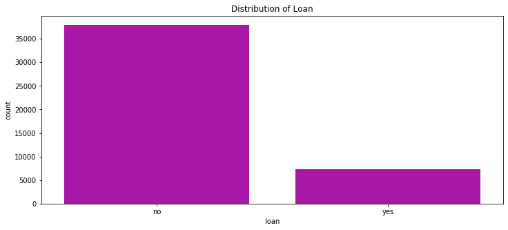

```python
plt.figure(figsize=(12,5))
plt.title("Distribution of Loan")
ax = sns.countplot(df["loan"], color = 'm')
```

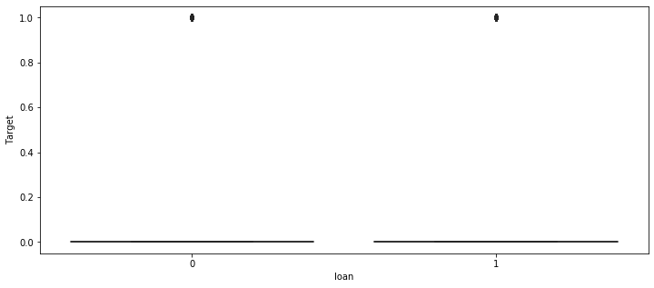

```python
# Univariant Analysis
plt.figure(figsize=(12,5))
sns.boxplot(x="loan",y="Target",data=dfCopiedData,color='g')
plt.show()
```

```python
dfCopiedData.head()
```

|  | age | job | marital | education | default | balance | housing | loan | contact | day | month | duration | campaign | pdays | previous | poutcome | Target |
| --- | --- | --- | --- | --- | --- | --- | --- | --- | --- | --- | --- | --- | --- | --- | --- | --- | --- |
| 0 | 58 | management | married | tertiary | 0 | 2143 | 1 | 0 | unknown | 5 | may | 261 | 1 | -1 | 0 | unknown | 0 |
| 1 | 44 | technician | single | secondary | 0 | 29 | 1 | 0 | unknown | 5 | may | 151 | 1 | -1 | 0 | unknown | 0 |
| 2 | 33 | entrepreneur | married | secondary | 0 | 2 | 1 | 1 | unknown | 5 | may | 76 | 1 | -1 | 0 | unknown | 0 |
| 3 | 47 | blue-collar | married | unknown | 0 | 1506 | 1 | 0 | unknown | 5 | may | 92 | 1 | -1 | 0 | unknown | 0 |
| 4 | 33 | unknown | single | unknown | 0 | 1 | 0 | 0 | unknown | 5 | may | 198 | 1 | -1 | 0 | unknown | 0 |

```python
# Contact
```

```python
dfCopiedData['contact'].dtype
```

```
dtype('O')
```

```python
dfCopiedData['contact'].value_counts()
```

```
cellular     29285
unknown      13020
telephone     2906
Name: contact, dtype: int64
```

```python
# Convert contact to numeric by level encoding
```

```python
dfCopiedData['contact']=dfCopiedData['contact'].astype('category')
dfCopiedData['contact']=dfCopiedData['contact'].cat.codes
dfCopiedData['contact'].value_counts()
```

```
0    29285
2    13020
1     2906
Name: contact, dtype: int64
```

```python
DtypeOfcontactVAriable=dfCopiedData['contact'].dtype
DtypeOfcontactVAriable
```

```
dtype('int8')
```

```python
dfCopiedData['contact'].describe().transpose()
```

```
count    45211.000000
mean         0.640242
std          0.897951
min          0.000000
25%          0.000000
50%          0.000000
75%          2.000000
max          2.000000
Name: contact, dtype: float64
```

```python
dfCopiedData['contact'].tail()
```

```
45206    0
45207    0
45208    0
45209    1
45210    0
Name: contact, dtype: int8
```

```python
dfCopiedData['contact'].isna().sum()
```

```
0
```

```python
dfCopiedData['contact'].isnull().sum()
```

```
0
```

```python
dfCopiedData['contact'].value_counts()
```

```
0    29285
2    13020
1     2906
Name: contact, dtype: int64
```

```python
dfCopiedData['contact'].value_counts().sum()
```

```
45211
```

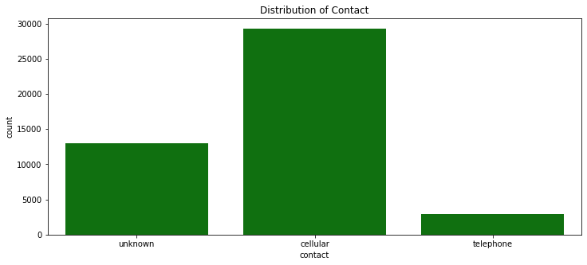

```python
plt.figure(figsize=(12,5))
plt.title("Distribution of Contact")
ax = sns.countplot(df["contact"], color = 'g')
```

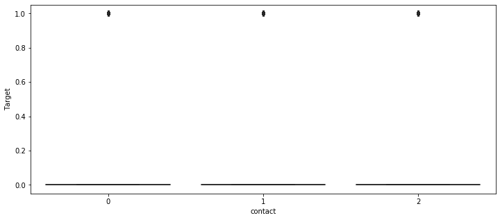

```python
# Univariant Analysis
plt.figure(figsize=(12,5))
sns.boxplot(x="contact",y="Target",data=dfCopiedData,color='g')
plt.show()
```

```python
dfCopiedData.head()
```

|  | age | job | marital | education | default | balance | housing | loan | contact | day | month | duration | campaign | pdays | previous | poutcome | Target |
| --- | --- | --- | --- | --- | --- | --- | --- | --- | --- | --- | --- | --- | --- | --- | --- | --- | --- |
| 0 | 58 | management | married | tertiary | 0 | 2143 | 1 | 0 | 2 | 5 | may | 261 | 1 | -1 | 0 | unknown | 0 |
| 1 | 44 | technician | single | secondary | 0 | 29 | 1 | 0 | 2 | 5 | may | 151 | 1 | -1 | 0 | unknown | 0 |
| 2 | 33 | entrepreneur | married | secondary | 0 | 2 | 1 | 1 | 2 | 5 | may | 76 | 1 | -1 | 0 | unknown | 0 |
| 3 | 47 | blue-collar | married | unknown | 0 | 1506 | 1 | 0 | 2 | 5 | may | 92 | 1 | -1 | 0 | unknown | 0 |
| 4 | 33 | unknown | single | unknown | 0 | 1 | 0 | 0 | 2 | 5 | may | 198 | 1 | -1 | 0 | unknown | 0 |

```python
# Day
```

```python
dfCopiedData['day'].dtype
```

```
dtype('int64')
```

```python
DtypeOfdayVAriable=dfCopiedData['day'].dtype
DtypeOfdayVAriable
```

```
dtype('int64')
```

```python
dfCopiedData['day'].describe().transpose()
```

```
count    45211.000000
mean        15.806419
std          8.322476
min          1.000000
25%          8.000000
50%         16.000000
75%         21.000000
max         31.000000
Name: day, dtype: float64
```

```python
dfCopiedData['day'].tail()
```

```
45206    17
45207    17
45208    17
45209    17
45210    17
Name: day, dtype: int64
```

```python
dfCopiedData['day'].isna().sum()
```

```
0
```

```python
dfCopiedData['day'].isnull().sum()
```

```
0
```

```python
dfCopiedData['day'].value_counts()
```

```
20    2752
18    2308
21    2026
17    1939
6     1932
5     1910
14    1848
8     1842
28    1830
7     1817
19    1757
29    1745
15    1703
12    1603
13    1585
```

[output cut: 17 more lines]

```python
dfCopiedData['day'].value_counts().sum()
```

```
45211
```

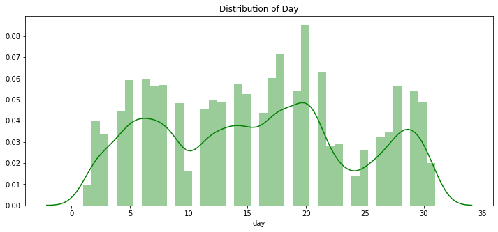

```python
plt.figure(figsize=(12,5))
plt.title("Distribution of Day")
ax = sns.distplot(dfCopiedData["day"], color = 'g')
```

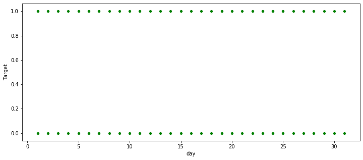

```python
plt.figure(figsize=(12,5))
sns.scatterplot(x="day",y="Target",data=dfCopiedData,color='g')
plt.show()
```

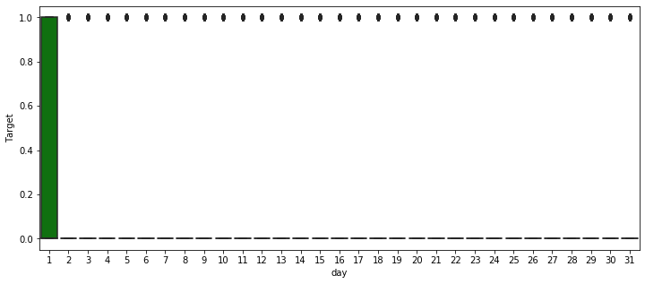

```python
plt.figure(figsize=(12,5))
sns.boxplot(x="day",y="Target",data=dfCopiedData,color='g')
plt.show()
```

```python
dfCopiedData.head()
```

|  | age | job | marital | education | default | balance | housing | loan | contact | day | month | duration | campaign | pdays | previous | poutcome | Target |
| --- | --- | --- | --- | --- | --- | --- | --- | --- | --- | --- | --- | --- | --- | --- | --- | --- | --- |
| 0 | 58 | management | married | tertiary | 0 | 2143 | 1 | 0 | 2 | 5 | may | 261 | 1 | -1 | 0 | unknown | 0 |
| 1 | 44 | technician | single | secondary | 0 | 29 | 1 | 0 | 2 | 5 | may | 151 | 1 | -1 | 0 | unknown | 0 |
| 2 | 33 | entrepreneur | married | secondary | 0 | 2 | 1 | 1 | 2 | 5 | may | 76 | 1 | -1 | 0 | unknown | 0 |
| 3 | 47 | blue-collar | married | unknown | 0 | 1506 | 1 | 0 | 2 | 5 | may | 92 | 1 | -1 | 0 | unknown | 0 |
| 4 | 33 | unknown | single | unknown | 0 | 1 | 0 | 0 | 2 | 5 | may | 198 | 1 | -1 | 0 | unknown | 0 |

```python
# month
```

```python
dfCopiedData['month'].dtype
```

```
dtype('O')
```

```python
dfCopiedData['month'].head()
```

```
0    may
1    may
2    may
3    may
4    may
Name: month, dtype: object
```

```python
dfCopiedData['month'].value_counts()
```

```
may    13766
jul     6895
aug     6247
jun     5341
nov     3970
apr     2932
feb     2649
jan     1403
oct      738
sep      579
mar      477
dec      214
Name: month, dtype: int64
```

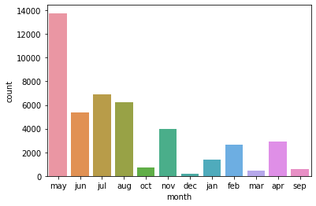

```python
sns.countplot(x='month',data=dfCopiedData)
```

```python
DtypeOfmonthVAriable=dfCopiedData['month'].dtype
DtypeOfmonthVAriable
```

```
dtype('O')
```

```python
dfCopiedData['month'].describe().transpose()
```

```
count     45211
unique       12
top         may
freq      13766
Name: month, dtype: object
```

```python
dfCopiedData['month'].tail()
```

```
45206    nov
45207    nov
45208    nov
45209    nov
45210    nov
Name: month, dtype: object
```

```python
dfCopiedData['month'].isna().sum()
```

```
0
```

```python
dfCopiedData['month'].isnull().sum()
```

```
0
```

```python
dfCopiedData['month'].value_counts()
```

```
may    13766
jul     6895
aug     6247
jun     5341
nov     3970
apr     2932
feb     2649
jan     1403
oct      738
sep      579
mar      477
dec      214
Name: month, dtype: int64
```

```python
dfCopiedData['month'].value_counts().sum()
```

```
45211
```

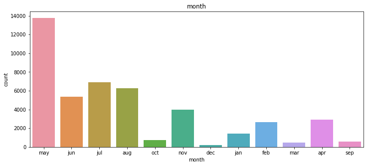

```python
plt.figure(figsize=(12,5))
plt.title('month')
sns.countplot(x='month',data=dfCopiedData)
plt.show()
```

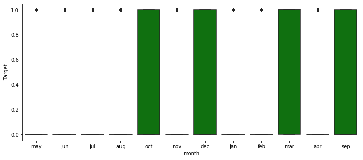

```python
# Univariant Analysis
plt.figure(figsize=(12,5))
sns.boxplot(x="month",y="Target",data=dfCopiedData,color='g')
plt.show()
```

```python
dfCopiedData.head()
```

|  | age | job | marital | education | default | balance | housing | loan | contact | day | month | duration | campaign | pdays | previous | poutcome | Target |
| --- | --- | --- | --- | --- | --- | --- | --- | --- | --- | --- | --- | --- | --- | --- | --- | --- | --- |
| 0 | 58 | management | married | tertiary | 0 | 2143 | 1 | 0 | 2 | 5 | may | 261 | 1 | -1 | 0 | unknown | 0 |
| 1 | 44 | technician | single | secondary | 0 | 29 | 1 | 0 | 2 | 5 | may | 151 | 1 | -1 | 0 | unknown | 0 |
| 2 | 33 | entrepreneur | married | secondary | 0 | 2 | 1 | 1 | 2 | 5 | may | 76 | 1 | -1 | 0 | unknown | 0 |
| 3 | 47 | blue-collar | married | unknown | 0 | 1506 | 1 | 0 | 2 | 5 | may | 92 | 1 | -1 | 0 | unknown | 0 |
| 4 | 33 | unknown | single | unknown | 0 | 1 | 0 | 0 | 2 | 5 | may | 198 | 1 | -1 | 0 | unknown | 0 |

```python
dfCopiedData['duration'].value_counts()
```

```
124     188
90      184
89      177
122     175
104     175
114     175
136     174
112     174
139     174
121     173
91      170
119     170
88      170
103     169
92      168
```

[output cut: 47 more lines]

```python
DtypeOfdurationVAriable=dfCopiedData['duration'].dtype
DtypeOfdurationVAriable
```

```
dtype('int64')
```

```python
dfCopiedData['duration'].describe().transpose()
```

```
count    45211.000000
mean       258.163080
std        257.527812
min          0.000000
25%        103.000000
50%        180.000000
75%        319.000000
max       4918.000000
Name: duration, dtype: float64
```

```python
dfCopiedData['duration'].tail()
```

```
45206     977
45207     456
45208    1127
45209     508
45210     361
Name: duration, dtype: int64
```

```python
dfCopiedData['duration'].isna().sum()
```

```
0
```

```python
dfCopiedData['duration'].isnull().sum()
```

```
0
```

```python
dfCopiedData['duration'].value_counts()
```

```
124     188
90      184
89      177
122     175
104     175
114     175
136     174
112     174
139     174
121     173
91      170
119     170
88      170
103     169
92      168
```

[output cut: 47 more lines]

```python
dfCopiedData['duration'].value_counts().sum()
```

```
45211
```

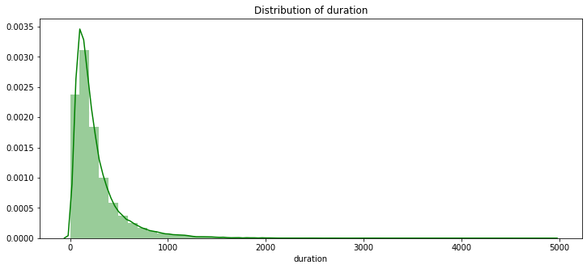

```python
plt.figure(figsize=(12,5))
plt.title("Distribution of duration")
ax = sns.distplot(dfCopiedData["duration"], color = 'g')
```

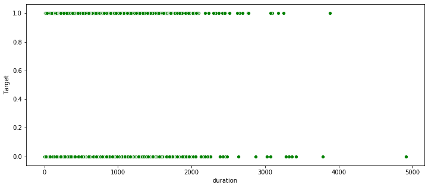

```python
# Univariant Analysis
plt.figure(figsize=(12,5))
sns.scatterplot(x="duration",y="Target",data=dfCopiedData,color='g')
plt.show()
```

```python
# Univariant Analysis
plt.figure(figsize=(12,5))
sns.boxplot(x="duration",y="Target",data=dfCopiedData,color='g')
plt.show()
```

[output not shown]

[output cut: 73 more lines]

[output not shown]

[output not shown]

[output not shown]

[output cut: 55 more lines]

[output not shown]

```python
dfCopiedData.head()
```

|  | age | job | marital | education | default | balance | housing | loan | contact | day | month | duration | campaign | pdays | previous | poutcome | Target |
| --- | --- | --- | --- | --- | --- | --- | --- | --- | --- | --- | --- | --- | --- | --- | --- | --- | --- |
| 0 | 58 | management | married | tertiary | 0 | 2143 | 1 | 0 | 2 | 5 | may | 261 | 1 | -1 | 0 | unknown | 0 |
| 1 | 44 | technician | single | secondary | 0 | 29 | 1 | 0 | 2 | 5 | may | 151 | 1 | -1 | 0 | unknown | 0 |
| 2 | 33 | entrepreneur | married | secondary | 0 | 2 | 1 | 1 | 2 | 5 | may | 76 | 1 | -1 | 0 | unknown | 0 |
| 3 | 47 | blue-collar | married | unknown | 0 | 1506 | 1 | 0 | 2 | 5 | may | 92 | 1 | -1 | 0 | unknown | 0 |
| 4 | 33 | unknown | single | unknown | 0 | 1 | 0 | 0 | 2 | 5 | may | 198 | 1 | -1 | 0 | unknown | 0 |

```python
# campaign
```

```python
dfCopiedData['campaign'].dtype
```

```
dtype('int64')
```

```python
dfCopiedData['campaign'].value_counts()
```

```
1     17544
2     12505
3      5521
4      3522
5      1764
6      1291
7       735
8       540
9       327
10      266
11      201
12      155
13      133
14       93
15       84
```

[output cut: 34 more lines]

```python
DtypeOfcampaignVAriable=dfCopiedData['campaign'].dtype
DtypeOfcampaignVAriable
```

```
dtype('int64')
```

```python
dfCopiedData['campaign'].describe().transpose()
```

```
count    45211.000000
mean         2.763841
std          3.098021
min          1.000000
25%          1.000000
50%          2.000000
75%          3.000000
max         63.000000
Name: campaign, dtype: float64
```

```python
dfCopiedData['campaign'].tail()
```

```
45206    3
45207    2
45208    5
45209    4
45210    2
Name: campaign, dtype: int64
```

```python
dfCopiedData['campaign'].isna().sum()
```

```
0
```

```python
dfCopiedData['campaign'].isnull().sum()
```

```
0
```

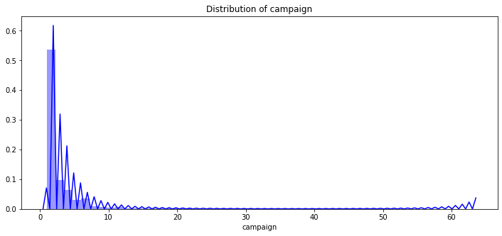

```python
plt.figure(figsize=(12,5))
plt.title("Distribution of campaign")
ax = sns.distplot(dfCopiedData["campaign"], color = 'b')
```

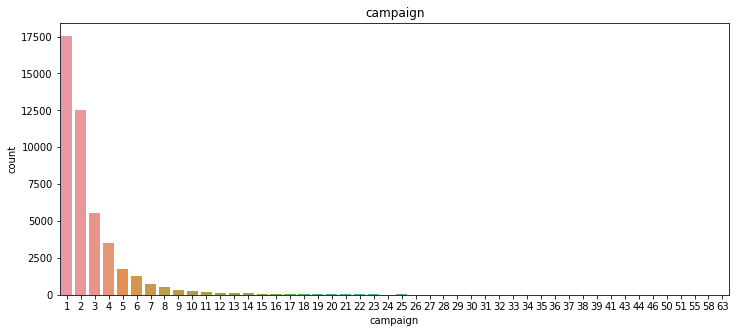

```python
plt.figure(figsize=(12,5))
plt.title('campaign')
sns.countplot(x='campaign',data=dfCopiedData)
plt.show()
```

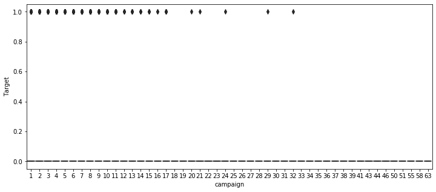

```python
# Univariant Analysis
plt.figure(figsize=(12,5))
sns.boxplot(x="campaign",y="Target",data=dfCopiedData,color='g')
plt.show()
```

```python
# pdays
```

```python
dfCopiedData.head()
```

|  | age | job | marital | education | default | balance | housing | loan | contact | day | month | duration | campaign | pdays | previous | poutcome | Target |
| --- | --- | --- | --- | --- | --- | --- | --- | --- | --- | --- | --- | --- | --- | --- | --- | --- | --- |
| 0 | 58 | management | married | tertiary | 0 | 2143 | 1 | 0 | 2 | 5 | may | 261 | 1 | -1 | 0 | unknown | 0 |
| 1 | 44 | technician | single | secondary | 0 | 29 | 1 | 0 | 2 | 5 | may | 151 | 1 | -1 | 0 | unknown | 0 |
| 2 | 33 | entrepreneur | married | secondary | 0 | 2 | 1 | 1 | 2 | 5 | may | 76 | 1 | -1 | 0 | unknown | 0 |
| 3 | 47 | blue-collar | married | unknown | 0 | 1506 | 1 | 0 | 2 | 5 | may | 92 | 1 | -1 | 0 | unknown | 0 |
| 4 | 33 | unknown | single | unknown | 0 | 1 | 0 | 0 | 2 | 5 | may | 198 | 1 | -1 | 0 | unknown | 0 |

```python
dfCopiedData['pdays'].dtype
```

```
dtype('int64')
```

```python
DtypeOfpdaysVAriable=dfCopiedData['pdays'].dtype
DtypeOfpdaysVAriable
```

```
dtype('int64')
```

```python
dfCopiedData['pdays'].describe().transpose()
```

```
count    45211.000000
mean        40.197828
std        100.128746
min         -1.000000
25%         -1.000000
50%         -1.000000
75%         -1.000000
max        871.000000
Name: pdays, dtype: float64
```

```python
dfCopiedData['pdays'].tail()
```

```
45206     -1
45207     -1
45208    184
45209     -1
45210    188
Name: pdays, dtype: int64
```

```python
dfCopiedData['pdays'].isna().sum()
```

```
0
```

```python
dfCopiedData['pdays'].isnull().sum()
```

```
0
```

```python
dfCopiedData['pdays'].value_counts()
```

```
-1      36954
 182      167
 92       147
 183      126
 91       126
 181      117
 370       99
 184       85
 364       77
 95        74
 350       73
 94        72
 175       71
 185       68
 93        65
```

[output cut: 47 more lines]

```python
dfCopiedData['pdays'].value_counts().sum()
```

```
45211
```

[figure not shown]

```python
plt.figure(figsize=(12,5))
plt.title('pdays')
sns.countplot(x='pdays',data=dfCopiedData)
plt.show()
```

[figure not shown]

```python
# Univariant Analysis
plt.figure(figsize=(12,5))
sns.boxplot(x="pdays",y="Target",data=dfCopiedData,color='g')
plt.show()
```

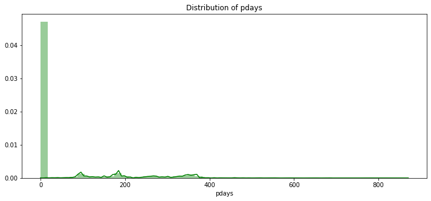

```python
plt.figure(figsize=(12,5))
plt.title("Distribution of pdays")
ax = sns.distplot(dfCopiedData["pdays"], color = 'g')
```

```python
# previous
```

```python
dfCopiedData['previous'].dtype
```

```
dtype('int64')
```

```python
DtypeOfpreviousVAriable=dfCopiedData['previous'].dtype
DtypeOfpreviousVAriable
```

```
dtype('int64')
```

```python
dfCopiedData['previous'].describe().transpose()
```

```
count    45211.000000
mean         0.580323
std          2.303441
min          0.000000
25%          0.000000
50%          0.000000
75%          0.000000
max        275.000000
Name: previous, dtype: float64
```

```python
dfCopiedData['previous'].tail()
```

```
45206     0
45207     0
45208     3
45209     0
45210    11
Name: previous, dtype: int64
```

```python
dfCopiedData['previous'].isna().sum()
```

```
0
```

```python
dfCopiedData['previous'].isnull().sum()
```

```
0
```

```python
dfCopiedData['previous'].value_counts()
```

```
0      36954
1       2772
2       2106
3       1142
4        714
5        459
6        277
7        205
8        129
9         92
10        67
11        65
12        44
13        38
15        20
```

[output cut: 27 more lines]

```python
dfCopiedData['previous'].value_counts().sum()
```

```
45211
```

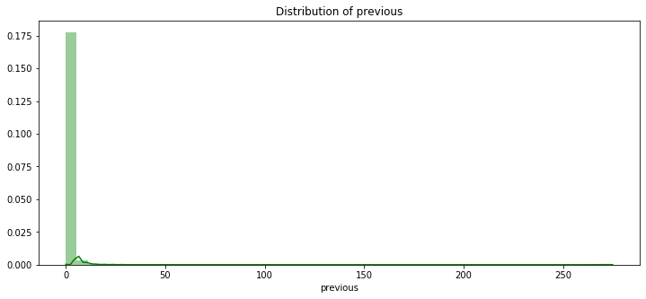

```python
plt.figure(figsize=(12,5))
plt.title("Distribution of previous")
ax = sns.distplot(dfCopiedData["previous"], color = 'g')
```

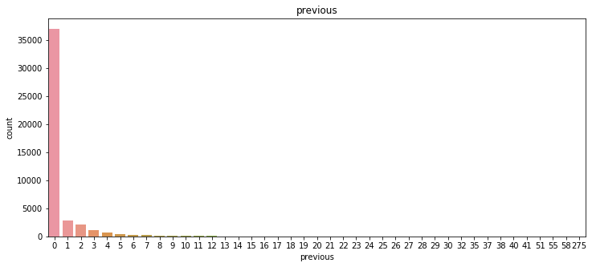

```python
plt.figure(figsize=(12,5))
plt.title('previous')
sns.countplot(x='previous',data=dfCopiedData)
plt.show()
```

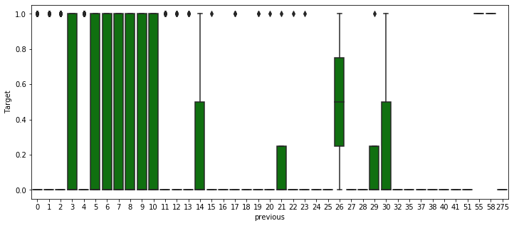

```python
# Univariant Analysis
plt.figure(figsize=(12,5))
sns.boxplot(x="previous",y="Target",data=dfCopiedData,color='g')
plt.show()
```

```python
# poutcome
```

```python
dfCopiedData['poutcome'].head()
```

```
0    unknown
1    unknown
2    unknown
3    unknown
4    unknown
Name: poutcome, dtype: object
```

```python
dfCopiedData['poutcome'].value_counts()
```

```
unknown    36959
failure     4901
other       1840
success     1511
Name: poutcome, dtype: int64
```

```python
# Changing to numeric by using one level coding
```

```python
dfCopiedData['poutcome']=dfCopiedData['poutcome'].astype('category')
dfCopiedData['poutcome']=dfCopiedData['poutcome'].cat.codes
dfCopiedData['poutcome'].head()
```

```
0    3
1    3
2    3
3    3
4    3
Name: poutcome, dtype: int8
```

```python
DtypeOfpoutcomeVAriable=dfCopiedData['poutcome'].dtype
DtypeOfpoutcomeVAriable
```

```
dtype('int8')
```

```python
dfCopiedData['poutcome'].describe().transpose()
```

```
count    45211.000000
mean         2.559974
std          0.989059
min          0.000000
25%          3.000000
50%          3.000000
75%          3.000000
max          3.000000
Name: poutcome, dtype: float64
```

```python
dfCopiedData['poutcome'].tail()
```

```
45206    3
45207    3
45208    2
45209    3
45210    1
Name: poutcome, dtype: int8
```

```python
dfCopiedData['poutcome'].isna().sum()
```

```
0
```

```python
dfCopiedData['poutcome'].isnull().sum()
```

```
0
```

```python
dfCopiedData['poutcome'].value_counts()
```

```
3    36959
0     4901
1     1840
2     1511
Name: poutcome, dtype: int64
```

```python
dfCopiedData['poutcome'].value_counts().sum()
```

```
45211
```

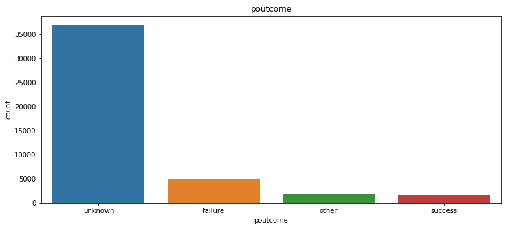

```python
plt.figure(figsize=(12,5))
plt.title('poutcome')
sns.countplot(x='poutcome',data=df)
plt.show()
```

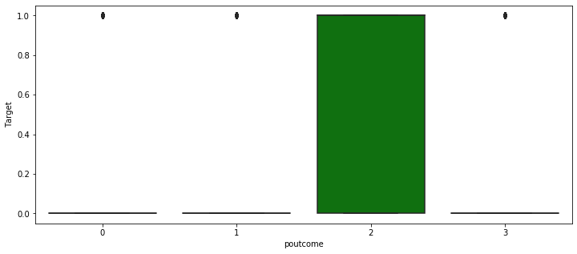

```python
# Univariant Analysis
plt.figure(figsize=(12,5))
sns.boxplot(x="poutcome",y="Target",data=dfCopiedData,color='g')
plt.show()
```

```python
df.head()
```

|  | age | job | marital | education | default | balance | housing | loan | contact | day | month | duration | campaign | pdays | previous | poutcome | Target |
| --- | --- | --- | --- | --- | --- | --- | --- | --- | --- | --- | --- | --- | --- | --- | --- | --- | --- |
| 0 | 58 | management | married | tertiary | no | 2143 | yes | no | unknown | 5 | may | 261 | 1 | -1 | 0 | unknown | no |
| 1 | 44 | technician | single | secondary | no | 29 | yes | no | unknown | 5 | may | 151 | 1 | -1 | 0 | unknown | no |
| 2 | 33 | entrepreneur | married | secondary | no | 2 | yes | yes | unknown | 5 | may | 76 | 1 | -1 | 0 | unknown | no |
| 3 | 47 | blue-collar | married | unknown | no | 1506 | yes | no | unknown | 5 | may | 92 | 1 | -1 | 0 | unknown | no |
| 4 | 33 | unknown | single | unknown | no | 1 | no | no | unknown | 5 | may | 198 | 1 | -1 | 0 | unknown | no |

```python
# Target
```

```python
df['Target'].dtype
```

```
dtype('O')
```

```python
df['Target'].value_counts()
```

```
no     39922
yes     5289
Name: Target, dtype: int64
```

```python
# Target all ready converted to numeric above
DtypeOfTargetVAriable=dfCopiedData['Target'].dtype
DtypeOfTargetVAriable
```

```
dtype('int8')
```

```python
dfCopiedData['Target'].describe().transpose()
```

```
count    45211.000000
mean         0.116985
std          0.321406
min          0.000000
25%          0.000000
50%          0.000000
75%          0.000000
max          1.000000
Name: Target, dtype: float64
```

```python
dfCopiedData['Target'].tail()
```

```
45206    1
45207    1
45208    1
45209    0
45210    0
Name: Target, dtype: int8
```

```python
dfCopiedData['Target'].isna().sum()
```

```
0
```

```python
dfCopiedData['Target'].isnull().sum()
```

```
0
```

```python
dfCopiedData['Target'].value_counts()
```

```
0    39922
1     5289
Name: Target, dtype: int64
```

```python
dfCopiedData['Target'].value_counts().sum()
```

```
45211
```

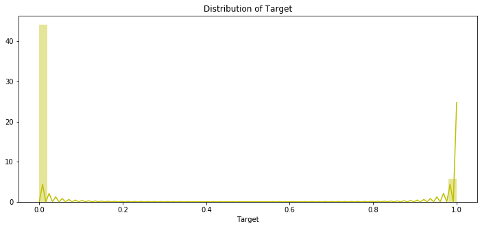

```python
plt.figure(figsize=(12,5))
plt.title("Distribution of Target")
ax = sns.distplot(dfCopiedData["Target"], color = 'y')
```

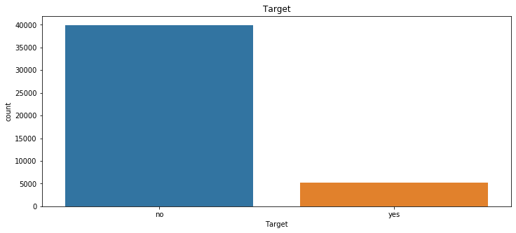

```python
plt.figure(figsize=(12,5))
plt.title('Target')
sns.countplot(x='Target',data=df)
plt.show()
```

```python
sns.pairplot(dfCopiedData)
```

[output not shown]

```python
###############################
```

# Deliverable – 2 (Prepare the data for analytics)

```python
# Split Data.70:30
from sklearn.model_selection import train_test_split
dfDataModelCreation=pd.read_csv("bank-full.csv")
```

```python
dfDataModelCreation.head()
```

|  | age | job | marital | education | default | balance | housing | loan | contact | day | month | duration | campaign | pdays | previous | poutcome | Target |
| --- | --- | --- | --- | --- | --- | --- | --- | --- | --- | --- | --- | --- | --- | --- | --- | --- | --- |
| 0 | 58 | management | married | tertiary | no | 2143 | yes | no | unknown | 5 | may | 261 | 1 | -1 | 0 | unknown | no |
| 1 | 44 | technician | single | secondary | no | 29 | yes | no | unknown | 5 | may | 151 | 1 | -1 | 0 | unknown | no |
| 2 | 33 | entrepreneur | married | secondary | no | 2 | yes | yes | unknown | 5 | may | 76 | 1 | -1 | 0 | unknown | no |
| 3 | 47 | blue-collar | married | unknown | no | 1506 | yes | no | unknown | 5 | may | 92 | 1 | -1 | 0 | unknown | no |
| 4 | 33 | unknown | single | unknown | no | 1 | no | no | unknown | 5 | may | 198 | 1 | -1 | 0 | unknown | no |

```python
# Change all categorical to numeric through one level encoding
dfDataModelCreation=pd.DataFrame({col:dfDataModelCreation[col].astype('category').cat.codes for col in dfDataModelCreation},index=dfDataModelCreation.index)
```

```python
dfDataModelCreation.head()
```

|  | age | job | marital | education | default | balance | housing | loan | contact | day | month | duration | campaign | pdays | previous | poutcome | Target |
| --- | --- | --- | --- | --- | --- | --- | --- | --- | --- | --- | --- | --- | --- | --- | --- | --- | --- |
| 0 | 40 | 4 | 1 | 2 | 0 | 3036 | 1 | 0 | 2 | 4 | 8 | 261 | 0 | 0 | 0 | 3 | 0 |
| 1 | 26 | 9 | 2 | 1 | 0 | 945 | 1 | 0 | 2 | 4 | 8 | 151 | 0 | 0 | 0 | 3 | 0 |
| 2 | 15 | 2 | 1 | 1 | 0 | 918 | 1 | 1 | 2 | 4 | 8 | 76 | 0 | 0 | 0 | 3 | 0 |
| 3 | 29 | 1 | 1 | 3 | 0 | 2420 | 1 | 0 | 2 | 4 | 8 | 92 | 0 | 0 | 0 | 3 | 0 |
| 4 | 15 | 11 | 2 | 3 | 0 | 917 | 0 | 0 | 2 | 4 | 8 | 198 | 0 | 0 | 0 | 3 | 0 |

```python
# Split Data.70:30

X = dfDataModelCreation.drop("Target" , axis=1)
Y = dfDataModelCreation.pop("Target")
X.head()
```

|  | age | job | marital | education | default | balance | housing | loan | contact | day | month | duration | campaign | pdays | previous | poutcome |
| --- | --- | --- | --- | --- | --- | --- | --- | --- | --- | --- | --- | --- | --- | --- | --- | --- |
| 0 | 40 | 4 | 1 | 2 | 0 | 3036 | 1 | 0 | 2 | 4 | 8 | 261 | 0 | 0 | 0 | 3 |
| 1 | 26 | 9 | 2 | 1 | 0 | 945 | 1 | 0 | 2 | 4 | 8 | 151 | 0 | 0 | 0 | 3 |
| 2 | 15 | 2 | 1 | 1 | 0 | 918 | 1 | 1 | 2 | 4 | 8 | 76 | 0 | 0 | 0 | 3 |
| 3 | 29 | 1 | 1 | 3 | 0 | 2420 | 1 | 0 | 2 | 4 | 8 | 92 | 0 | 0 | 0 | 3 |
| 4 | 15 | 11 | 2 | 3 | 0 | 917 | 0 | 0 | 2 | 4 | 8 | 198 | 0 | 0 | 0 | 3 |

```python
Y.head()
```

```
0    0
1    0
2    0
3    0
4    0
Name: Target, dtype: int8
```

```python
# Split Data.70:30
X_train,X_test,Y_train,Y_test=train_test_split(X,Y,test_size=.30, random_state=1)
```

**Deliverable – 3 (create the ensemble model). Use appropriate algorithms and explain why that algorithm in the comment lines.**

```python
from sklearn.preprocessing import StandardScaler
sc_X=StandardScaler()
X_train=sc_X.fit_transform(X_train)
X_test=sc_X.fit_transform(X_test)
```

**Logistic** **Definition: Logistic regression is a machine learning algorithm for classification. In this algorithm, the probabilities describing the possible outcomes of a single trial are modelled using a logistic function.**

**Advantages: Logistic regression is designed for this purpose (classification), and is most useful for understanding the influence of several independent variables on a single outcome variable.**

**Disadvantages: Works only when the predicted variable is binary, assumes all predictors are independent of each other, and assumes data is free of missing values.**

```python
from sklearn.linear_model import LogisticRegression
classifier=LogisticRegression(random_state=0)
classifier.fit(X_train,Y_train)
```

```
LogisticRegression(C=1.0, class_weight=None, dual=False, fit_intercept=True,
                   intercept_scaling=1, l1_ratio=None, max_iter=100,
                   multi_class='warn', n_jobs=None, penalty='l2',
                   random_state=0, solver='warn', tol=0.0001, verbose=0,
                   warm_start=False)
```

```python
# predict test result
Y_predLogistic=classifier.predict(X_test)

Y_predLogistic
```

```
array([0, 0, 0, ..., 0, 0, 0], dtype=int8)
```

```python
y_scoreLogistic = classifier.decision_function(X_test)
y_scoreLogistic
```

```
array([-4.2323017 , -3.24283503, -0.93687326, ..., -2.4031998 ,
       -3.79511149, -1.6531976 ])
```

**Confusion Matrix**

```python
# MAking confusion matrix
# 1485 incorrect pred
from sklearn.metrics import confusion_matrix
cmLogistic=confusion_matrix(Y_test,Y_predLogistic)
cmLogistic
```

```
array([[11726,   287],
       [ 1198,   353]], dtype=int64)
```

**Accuracy**

```python
from sklearn.metrics import accuracy_score
accuracy=accuracy_score(Y_test,Y_predLogistic)*100
print(('Accuracy of Logistic Regression model is equal '+ str(round(accuracy, 2))) + ' %.')
```

```
Accuracy of Logistic Regression model is equal 89.05 %.
```

**KNN** **K-Nearest Neighbours**

**Definition: Neighbours based classification is a type of lazy learning as it does not attempt to construct a general internal model, but simply stores instances of the training data. Classification is computed from a simple majority vote of the k nearest neighbours of each point.**

**Advantages: This algorithm is simple to implement, robust to noisy training data, and effective if training data is large.**

**Disadvantages: Need to determine the value of K and the computation cost is high as it needs to computer the distance of each instance to all the training samples.**

```python
#Mertic selected as minkowski as we need to consider Euclidian metric.
from sklearn.neighbors import KNeighborsClassifier
classifier=KNeighborsClassifier(n_neighbors=5,metric='minkowski',p=2)
classifier.fit(X_train,Y_train)
```

```
KNeighborsClassifier(algorithm='auto', leaf_size=30, metric='minkowski',
                     metric_params=None, n_jobs=None, n_neighbors=5, p=2,
                     weights='uniform')
```

```python
Y_predKNN=classifier.predict(X_test)
Y_predKNN
```

```
array([0, 0, 0, ..., 0, 0, 0], dtype=int8)
```

**Confusion Matrix**

```python
cmKNN=confusion_matrix(Y_test,Y_predKNN)
cmKNN
```

```
array([[11668,   345],
       [ 1033,   518]], dtype=int64)
```

**Accuracy**

```python
accuracy=accuracy_score(Y_test,Y_predKNN)*100
print('Accuracy of KNN model is equal ' + str(round(accuracy, 2)) + ' %.')
```

```
Accuracy of KNN model is equal 89.84 %.
```

**Naive Bayes**

**Definition: Naive Bayes algorithm based on Bayes’ theorem with the assumption of independence between every pair of features. Naive Bayes classifiers work well in many real-world situations such as document classification and spam filtering.**

**Advantages: This algorithm requires a small amount of training data to estimate the necessary parameters. Naive Bayes classifiers are extremely fast compared to more sophisticated methods.**

**Disadvantages: Naive Bayes is is known to be a bad estimator.**

```python
from sklearn.naive_bayes import GaussianNB
classifier=GaussianNB()
classifier.fit(X_train,Y_train)
```

```
GaussianNB(priors=None, var_smoothing=1e-09)
```

```python
Y_predNaive=classifier.predict(X_test)
Y_predNaive
```

```
array([0, 0, 1, ..., 0, 0, 0], dtype=int8)
```

**Confusion Matrix**

```python
cmNaive=confusion_matrix(Y_test,Y_predNaive)
cmNaive
```

```
array([[10531,  1482],
       [  735,   816]], dtype=int64)
```

**Accuracy**

```python
accuracy=accuracy_score(Y_test,Y_predNaive)*100
print('Accuracy of Naive Bayes is equal ' + str(round(accuracy, 2)) + ' %.')
```

```
Accuracy of Naive Bayes is equal 83.66 %.
```

**Stochastic Gradient Descent**

**Definition: Stochastic gradient descent is a simple and very efficient approach to fit linear models. It is particularly useful when the number of samples is very large. It supports different loss functions and penalties for classification.**

**Advantages: Efficiency and ease of implementation.**

**Disadvantages: Requires a number of hyper-parameters and it is sensitive to feature scaling.**

```python
from sklearn.linear_model import SGDClassifier
sgd=SGDClassifier(loss='modified_huber',shuffle=True,random_state=101)
sgd.fit(X_train,Y_train)
Y_predGD=sgd.predict(X_test)
```

**Confusion Matrix**

```python
cmGD=confusion_matrix(Y_test,Y_predGD)
cmGD
```

```
array([[11611,   402],
       [ 1091,   460]], dtype=int64)
```

**Accuracy**

```python
accuracy=accuracy_score(Y_test,Y_predGD)*100
print('Accuracy of Stochastic Gradient Descent is equal ' + str(round(accuracy, 2)) + ' %.')
```

```
Accuracy of Stochastic Gradient Descent is equal 88.99 %.
```

**Support Vector Machine**

**Support vector machine is a representation of the training data as points in space separated into categories by a clear gap that is as wide as possible. New examples are then mapped into that same space and predicted to belong to a category based on which side of the gap they fall.**

**Advantages: Effective in high dimensional spaces and uses a subset of training points in the decision function so it is also memory efficient.**

**Disadvantages: The algorithm does not directly provide probability estimates, these are calculated using an expensive five-fold cross-validation.**

```python
from sklearn.svm import SVC
svm=SVC(kernel='linear',C=0.025,random_state=101)
svm.fit(X_train,Y_train)
Y_predSVM=svm.predict(X_test)
```

```python
cmSVM=confusion_matrix(Y_test,Y_predSVM)
cmSVM
```

```
array([[12013,     0],
       [ 1551,     0]], dtype=int64)
```

```python
accuracy_score(Y_test,Y_predSVM)*100
print('Accuracy of Support Vector Machine is equal ' + str(round(accuracy, 2)) + ' %.')
```

[output not shown]

## Build Decision Tree Model

We will build our model using the DecisionTreeClassifier function. Using default 'gini' criteria to split. Other option include 'entropy'.

```python
from sklearn.tree import DecisionTreeClassifier
from sklearn import tree
from os import system
from IPython.display import Image
```

```python
dTree=DecisionTreeClassifier(criterion='gini',random_state=1)
dTree.fit(X_train,Y_train)
```

```
DecisionTreeClassifier(class_weight=None, criterion='gini', max_depth=None,
                       max_features=None, max_leaf_nodes=None,
                       min_impurity_decrease=0.0, min_impurity_split=None,
                       min_samples_leaf=1, min_samples_split=2,
                       min_weight_fraction_leaf=0.0, presort=False,
                       random_state=1, splitter='best')
```

## Scoring our Decision Tree

```python
print(dTree.score(X_train,Y_train))
print(dTree.score(X_test,Y_test))
```

```
1.0
0.8719404305514598
```

## Reducing over fitting (Regularization)

```python
dTreeR=DecisionTreeClassifier(criterion='gini',max_depth=3,random_state=1)
dTreeR.fit(X_train,Y_train)
print(dTreeR.score(X_train,Y_train))
print(dTreeR.score(X_test,Y_test))
```

```
0.8909849274812779
0.8905927455028015
```

```python
# importance of features in the tree building ( The importance of a feature is computed as the
#(normalized) total reduction of the criterion brought by that feature. It is also known as the Gini importance
print (pd.DataFrame(dTreeR.feature_importances_))
```

```
           0
0   0.087749
1   0.000000
2   0.000000
3   0.000000
4   0.000000
5   0.000000
6   0.000000
7   0.000000
8   0.040253
9   0.000000
10  0.142030
11  0.729968
12  0.000000
13  0.000000
14  0.000000
15  0.000000
```

```python
Y_predDecisionTree=dTreeR.predict(X_test)
Y_predDecisionTree
```

```
array([0, 0, 1, ..., 0, 0, 1], dtype=int8)
```

```python
# confusion Metrix
cmDecisonTree=confusion_matrix(Y_test,Y_predDecisionTree)
cmDecisonTree
```

```
array([[11738,   275],
       [ 1209,   342]], dtype=int64)
```

```python
# accuracy
accuracy_score(Y_test,Y_predDecisionTree)*100
print('Accuracy of Decision Tree is equal ' + str(round(accuracy, 2)) + ' %.')
```

[output not shown]

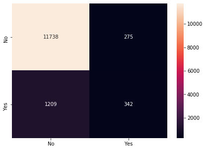

```python
from sklearn import metrics
cm=metrics.confusion_matrix(Y_test, Y_predDecisionTree, labels=[0, 1])

df_cm = pd.DataFrame(cm, index = [i for i in ["No","Yes"]],
                  columns = [i for i in ["No","Yes"]])
plt.figure(figsize = (7,5))
sns.heatmap(df_cm, annot=True ,fmt='g')
```

# Ensemble Learning - Bagging

```python
from sklearn.ensemble import BaggingClassifier

bgcl = BaggingClassifier(base_estimator=dTree, n_estimators=50,random_state=1)


bgcl = bgcl.fit(X_train, Y_train)
```

```python
Y_predBagging=bgcl.predict(X_test)
Y_predBagging
```

```
array([0, 0, 0, ..., 0, 0, 1], dtype=int8)
```

```python
print(bgcl.score(X_train,Y_train))
print(bgcl.score(X_test,Y_test))
```

```
0.9998104085695326
0.9031259215570628
```

```python
# confusion matrix
cmBagging=confusion_matrix(Y_test,Y_predBagging)
cmBagging
```

```
array([[11518,   495],
       [  819,   732]], dtype=int64)
```

```python
# accuracy
accuracy_score(Y_test,Y_predBagging)*100
print('Accuracy of Bagging is equal ' + str(round(accuracy, 2)) + ' %.')
```

[output not shown]

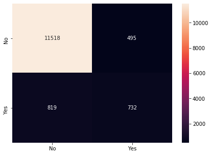

```python
cm=metrics.confusion_matrix(Y_test, Y_predBagging,labels=[0, 1])

df_cm = pd.DataFrame(cm, index = [i for i in ["No","Yes"]],
                  columns = [i for i in ["No","Yes"]])
plt.figure(figsize = (7,5))
sns.heatmap(df_cm, annot=True ,fmt='g')
```

# Ensemble Learning - AdaBoosting

```python
from sklearn.ensemble import AdaBoostClassifier
abcl = AdaBoostClassifier(n_estimators=10, random_state=1)
#abcl = AdaBoostClassifier( n_estimators=50,random_state=1)
abcl = abcl.fit(X_train, Y_train)
```

```
0.8849159539958714
```

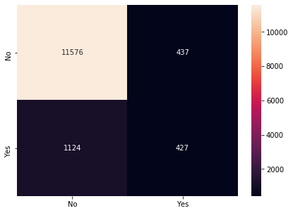

```python
Y_predAdaBoost = abcl.predict(X_test)
print(abcl.score(X_test , Y_test))

cm=metrics.confusion_matrix(Y_test, Y_predAdaBoost,labels=[0, 1])

df_cm = pd.DataFrame(cm, index = [i for i in ["No","Yes"]],
                  columns = [i for i in ["No","Yes"]])
plt.figure(figsize = (7,5))
sns.heatmap(df_cm, annot=True ,fmt='g')
```

# Confusion Matrix

```python
cmAdaBoost=confusion_matrix(Y_test,Y_predAdaBoost)
cmAdaBoost
```

```
array([[11576,   437],
       [ 1124,   427]], dtype=int64)
```

# Accuracy

```python
accuracy=accuracy_score(Y_test,Y_predAdaBoost)*100
print('Accuracy of AdaBoost is equal ' + str(round(accuracy, 2)) + ' %.')
```

```
Accuracy of AdaBoost is equal 88.49 %.
```